# Aula de laboratório - Escolha Qualitativa

Autor

Rafael Bressan

Data de Publicação

7 de agosto de 2023

```r
library(wooldridge)
library(fixest)
library(modelsummary)
library(ggplot2)
data("mroz")
```

## Modelo de Probabilidade Linear

Vamos analizar participação na força de trabalho de mulheres casadas com os dados `mroz` do pacote `wooldridge`. Nossa variável dependente será o status de participação na força de trabalho, $inlf\in\{0, 1\}$.

Se uma variável *dummy* é usada como variável dependente, nós podemos usar MQO para estimar a relação desta com os regressores normalmente. A probabilidade condicional de ocorrência do evento é:

$$P(y=1|x)=E[y|x]=\beta_0 + \beta_1 x$$

A interpretação dos coeficientes é direta, um aumento de uma unidade em $x$ provoca um aumento médio na probabilidade do evento de $\beta_1$. Modelos MPL sofrem de heterocedasticidade e, portanto, devemos utilizar erros padrão robustos.

**Cheque a estrutura dos dados com uma tabela de estatísticas descritivas.**

*Prompt*

`crie uma tabela de estatísticas descritivas para todas as variáveis do conjunto de dados mroz utilizando a função datasummary do pacote modelsummary. As estatísticas devem ser número de observações, número de valores únicos, média e desvio padrão.`

**Código**

```r
datasummary(All(mroz) ~ Ncol + NUnique + Mean + SD, data = mroz)
```

|  | Ncol | NUnique | Mean | SD |
| --- | --- | --- | --- | --- |
| inlf | (N = 753) | 2 | 0.57 | 0.50 |
| hours | (N = 753) | 306 | 740.58 | 871.31 |
| kidslt6 | (N = 753) | 4 | 0.24 | 0.52 |
| kidsge6 | (N = 753) | 9 | 1.35 | 1.32 |
| age | (N = 753) | 31 | 42.54 | 8.07 |
| educ | (N = 753) | 13 | 12.29 | 2.28 |
| wage | (N = 753) | 374 | 4.18 | 3.31 |
| repwage | (N = 753) | 164 | 1.85 | 2.42 |
| hushrs | (N = 753) | 422 | 2267.27 | 595.57 |
| husage | (N = 753) | 31 | 45.12 | 8.06 |
| huseduc | (N = 753) | 15 | 12.49 | 3.02 |
| huswage | (N = 753) | 697 | 7.48 | 4.23 |
| faminc | (N = 753) | 613 | 23080.59 | 12190.20 |
| mtr | (N = 753) | 22 | 0.68 | 0.08 |
| motheduc | (N = 753) | 9 | 9.25 | 3.37 |
| fatheduc | (N = 753) | 9 | 8.81 | 3.57 |
| unem | (N = 753) | 7 | 8.62 | 3.11 |
| city | (N = 753) | 2 | 0.64 | 0.48 |
| exper | (N = 753) | 40 | 10.63 | 8.07 |
| nwifeinc | (N = 753) | 706 | 20.13 | 11.63 |
| lwage | (N = 753) | 374 | 1.19 | 0.72 |
| expersq | (N = 753) | 40 | 178.04 | 249.63 |

**Agora faça a regressão da *dummy* de presença na força de trabalho em relação as seguintes variáveis: nwifeinc, educ, exper, exper^2, age, kidslt6, kidsge6.**

*Prompt*

`faça uma regressão linear da variável inlf em relação as variáveis nwifeinc, educ, exper, exper^2, age, kidslt6, kidsge6. Os erros padrão reportados devem ser robustos. Utilize o pacote fixest.`

**Código**

```r
fml <- inlf~nwifeinc + educ + exper + I(exper^2) + age + kidslt6 + kidsge6
mpl <- feols(fml,
    data = mroz,
    vcov = "HC1"
)
msummary(mpl)
```

|  | (1) |
| --- | --- |
| (Intercept) | 0.586 |
|  | (0.152) |
| nwifeinc | -0.003 |
|  | (0.002) |
| educ | 0.038 |
|  | (0.007) |
| exper | 0.039 |
|  | (0.006) |
| I(exper^2) | -0.001 |
|  | (0.000) |
| age | -0.016 |
|  | (0.002) |
| kidslt6 | -0.262 |
|  | (0.032) |
| kidsge6 | 0.013 |
|  | (0.014) |
| Num.Obs. | 753 |
| R2 | 0.264 |
| R2 Adj. | 0.257 |
| AIC | 863.8 |
| BIC | 900.8 |
| RMSE | 0.42 |
| Std.Errors | Heteroskedasticity-robust |

Por construção, um modelo MPL pode render previsão de probabilidade fora do intervalo $\left[0,1\right]$ para uma certa combinação de regressores (que pode ser realista ou não).

Como exemplo, supomos duas mulheres, a primeira com 20 anos, sem experiência, 5 anos de educação, 2 crianças com menos de 6 anos e renda de $ 100 (em milhares). A segunda mulher possui 52 anos, 30 anos de experiência e 17 de educação, sem crianças e renda.

**Faça a previsão de probabilidade de estarem no mercado de trabalho para ambas hipotéticas mulheres.**

*Prompt*

`com base na regressão anterior, faça a previsão de probabilidade de estarem no mercado de trabalho para duas mulheres hipotéticas. A primeira com 20 anos, sem experiência, 5 anos de educação, 2 crianças com menos de 6 anos e renda de $ 100 (em milhares). A segunda mulher possui 52 anos, 30 anos de experiência e 17 de educação, sem crianças e renda.`

```r
xpred <- data.frame(
    nwifeinc = c(100, 0),
    educ = c(5, 17),
    exper = c(0, 30),
    age = c(20, 52),
    kidslt6 = c(2, 0),
    kidsge6 = c(0, 0)
)
predict(mpl, newdata = xpred)
```

```
[1] -0.4104582  1.0428084
```

## Modelos Logit e Probit

Estes são modelos especializados em variáveis dependentes binárias e, portanto, não sofrem do problema de predição de probabilidade fora do intervalo $\left[0,1\right]$. A um indexador linear, estes modelos aplicam uma função (não-linear) que garante $y\in \left[0,1\right]$. Esta é chamada de função *link*.

- no modelo **probit** a função link é $G(z)=\Phi(z)$, a função de distribuição da Normal, e;
- no modelo **logit** a função link é $G(z)=\Lambda(z)=\frac{\exp(z)}{1+\exp(z)}$, a função de distribuição Logística.

Desta forma, a probabilidade do evento é definida como:

$$P(y=1|x)=G(\beta_0 + \beta_1 x)$$

No `R` estimamos esses modelos através da função `glm`, de *Generalized Linear Models*, especificando o argumento `family`. Vejamos um exemplo.

```r
logit <- glm(fml,
    data = mroz,
    family = binomial(link = logit)
)

probit <- glm(fml,
    data = mroz,
    family = binomial(link = probit)
)

msummary(list(Logit = logit, Probit = probit))
```

|  | Logit | Probit |
| --- | --- | --- |
| (Intercept) | 0.425 | 0.270 |
|  | (0.860) | (0.508) |
| nwifeinc | -0.021 | -0.012 |
|  | (0.008) | (0.005) |
| educ | 0.221 | 0.131 |
|  | (0.043) | (0.025) |
| exper | 0.206 | 0.123 |
|  | (0.032) | (0.019) |
| I(exper^2) | -0.003 | -0.002 |
|  | (0.001) | (0.001) |
| age | -0.088 | -0.053 |
|  | (0.015) | (0.008) |
| kidslt6 | -1.443 | -0.868 |
|  | (0.204) | (0.118) |
| kidsge6 | 0.060 | 0.036 |
|  | (0.075) | (0.044) |
| Num.Obs. | 753 | 753 |
| AIC | 819.5 | 818.6 |
| BIC | 856.5 | 855.6 |
| Log.Lik. | -401.765 | -401.302 |
| F | 21.785 | 25.501 |
| RMSE | 0.42 | 0.42 |

Uma forma visual de apresentar os resultados de uma regressão é através de um gráfico de coeficientes (coefficients plot). Este gráfico mostra a estimativa pontual acompanhada de uma barra denotando o intervalo de confiança (e.g. 90%). É muito utilizado em apresentações sobre a pesquisa ou estudo sendo realizada.

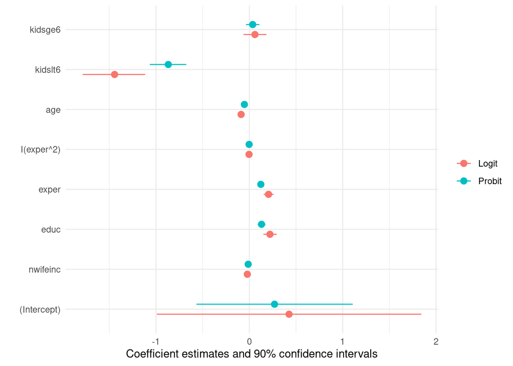

```r
modelplot(list(Logit = logit, Probit = probit),
    conf_level = 0.9
)
```

Podemos fazer a previsão da probabilidade das mesmas mulheres anteriores estarem no mercado de trabalho.

```r
predict(logit, newdata = xpred, type = "response")
```

```
          1           2
0.005218002 0.950049117
```

```r
predict(probit, newdata = xpred, type = "response")
```

```
          1           2
0.001065043 0.959869044
```

As previsões de logit e probit são semelhantes, mas especialmente nas caudas elas podem diferirem de forma significativa. O comando `predict` também pode retornar o valor do índice linear ($\hat\beta_0 + \hat\beta_1 x_i$) quando o argumento for type = “link”

```r
predict(logit, newdata = xpred, type = "link")
```

```
        1         2
-5.250409  2.945474
```

```r
predict(probit, newdata = xpred, type = "link")
```

```
        1         2
-3.071468  1.749168
```

**Simule valores para o índice linear entre -5 e 5 e plote qual seriam as respostas em probabilidades dos modelos logit e probit.**

*Prompt*

`simule a resposta de um modelo logit e outro probit para valores do índice linear entre -5 e 5 e plote as respostas em probabilidades dos modelos utilizando o ggplot.`

**Código**

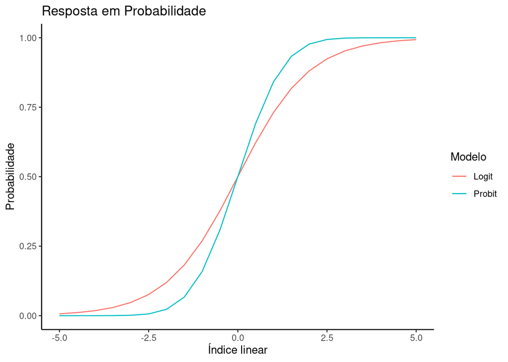

```r
index <- seq(-5, 5, by = 0.5)
logit_response <- plogis(index)
probit_response <- pnorm(index)
df <- data.frame(index, logit_response, probit_response)

ggplot(df, aes(x = index)) +
    geom_line(aes(y = logit_response, color = "Logit")) +
    geom_line(aes(y = probit_response, color = "Probit")) +
    guides(color = guide_legend(title = "Modelo")) +
    labs(
        x = "Índice linear",
        y = "Probabilidade",
        title = "Resposta em Probabilidade"
    ) +
    theme_classic()
```

## Efeitos Parciais

Os parâmetros de modelos não-lineares como logit e probit não possuem uma interpretação direta dos efeitos *ceteris paribus* do regressor sobre a variável dependente. Uma medida utilizada é o efeito parcial (ou efeito marginal) que é dependente do ponto $x_i$ em que se faz a análise. Este efeito marginal é equivalente a inclinação da curva de resposta do modelo em um determinado ponto.

$$\begin{align}
\frac{\partial\hat y}{\partial x}&=\frac{\partial G(x\hat\beta)}{\partial x}\\
&=\hat\beta \cdot g(x\hat\beta)
\end{align}$$

Onde é possível verificar que o efeito marginal depende tanto do valor estimado $\hat\beta$ quanto do ponto onde se faz a análise, $x$. O fato de este efeito diferir por valor do regressor faz com que seja difícil apresentar os resultados de uma maneira concisa. Adota-se, em geral, duas medidas de efeito parcial:

- Efeito Parcial na Média (PEA): $PEA(X_j)=g(\bar{x} \beta) \beta_j$
- Efeito Parcial Médio (APE): $APE(X_j)=\frac{1}{n} \sum_{i=1}^N g(x_i \beta) \beta_j$

**Calcule manualmente o PEA do modelo logit**

```r
# Ponto médio dos regressores
regressors <- c("nwifeinc", "educ", "exper", "age", "kidslt6", "kidsge6")
x_mean <- mroz[, regressors] |>
    colMeans()
betas <- coef(logit)
# x_mean deve conter 1 na primeira posicao e exper^2 na quinta
x_mean <- c(1, x_mean[1:3], mean(mroz[, "exper"]^2), x_mean[4:6])
# xb
index_mean <- sum(x_mean * betas)
# Agora o PEA
print("PEA de cada regressor é:")
```

```
[1] "PEA de cada regressor é:"
```

```r
dlogis(index_mean) * betas
```

```
  (Intercept)      nwifeinc          educ         exper    I(exper^2)
 0.1034482321 -0.0051900534  0.0537773087  0.0500569282 -0.0007669166
          age       kidslt6       kidsge6
-0.0214030205 -0.3509498193  0.0146162143
```

```r
# usando o pacote mfx
mfx::logitmfx(fml, data = mroz, atmean = TRUE)
```

```
Call:
mfx::logitmfx(formula = fml, data = mroz, atmean = TRUE)

Marginal Effects:
                 dF/dx   Std. Err.       z     P>|z|
nwifeinc   -0.00519005  0.00204820 -2.5340  0.011278 *
educ        0.05377731  0.01056074  5.0922 3.539e-07 ***
exper       0.05005693  0.00782462  6.3974 1.581e-10 ***
I(exper^2) -0.00076692  0.00024768 -3.0965  0.001959 **
age        -0.02140302  0.00353973 -6.0465 1.480e-09 ***
kidslt6    -0.35094982  0.04963897 -7.0700 1.549e-12 ***
kidsge6     0.01461621  0.01818832  0.8036  0.421625
---
Signif. codes:  0 '***' 0.001 '**' 0.01 '*' 0.05 '.' 0.1 ' ' 1
```

**Calcule manualmente o APE do modelo logit**

```r
g_mean <- predict(logit) |>
    dlogis() |>
    mean()
print("APE de cada regressor é:")
```

```
[1] "APE de cada regressor é:"
```

```r
betas * g_mean
```

```
  (Intercept)      nwifeinc          educ         exper    I(exper^2)
 0.0759771297 -0.0038118135  0.0394965238  0.0367641056 -0.0005632587
          age       kidslt6       kidsge6
-0.0157193606 -0.2577536551  0.0107348186
```

```r
# usando o pacote mfx
mfx::logitmfx(fml, data = mroz, atmean = FALSE)
```

```
Call:
mfx::logitmfx(formula = fml, data = mroz, atmean = FALSE)

Marginal Effects:
                 dF/dx   Std. Err.       z     P>|z|
nwifeinc   -0.00381181  0.00153898 -2.4769  0.013255 *
educ        0.03949652  0.00846811  4.6641 3.099e-06 ***
exper       0.03676411  0.00655577  5.6079 2.048e-08 ***
I(exper^2) -0.00056326  0.00018795 -2.9968  0.002728 **
age        -0.01571936  0.00293269 -5.3600 8.320e-08 ***
kidslt6    -0.25775366  0.04263493 -6.0456 1.489e-09 ***
kidsge6     0.01073482  0.01339130  0.8016  0.422769
---
Signif. codes:  0 '***' 0.001 '**' 0.01 '*' 0.05 '.' 0.1 ' ' 1
```